# Twitch Streamer Report

CARLS Craig, Adi, Ronan, Lauren, and Sophia

2022-11-30

## Twitch Streamer Report

### Our Data

*We started off by picking the twitch streamers dataset which we got through Awesome Public Datasets and downloaded from Kaggle. We decided to go with this dataset as we thought it would be very interesting to look at data from a recently introduced platform that has not been studied in excessive detail.*

```r
twitchdata <- read.csv("twitchdata-update.csv")
```

## What is Twitch?

*Twitch is an American company with a particular focus on gaming and live streaming content.A twitch streamer is someone who uses the platform Twitch to livestream content to others across the world.*

## Hypothesis

*Our initial hypothesis was to identify the correlation between stream time and watch time as well as followers gained. To do so we started off by compiling a list of the primary language used by the streamers and the frequency of them. This was then put into a table and we discovered that the number of people who spoke each language ranged from 1 to 485, with English being the widest spoken language at 485. While this is interesting English is the most widely spoken with the next one down being Korean at 77. This would make language comparisons difficult as English dominates the data greatly and thus English would be over represented in analysis linked to language. This prompted our decision to focus mainly on streamers who spoke English.*

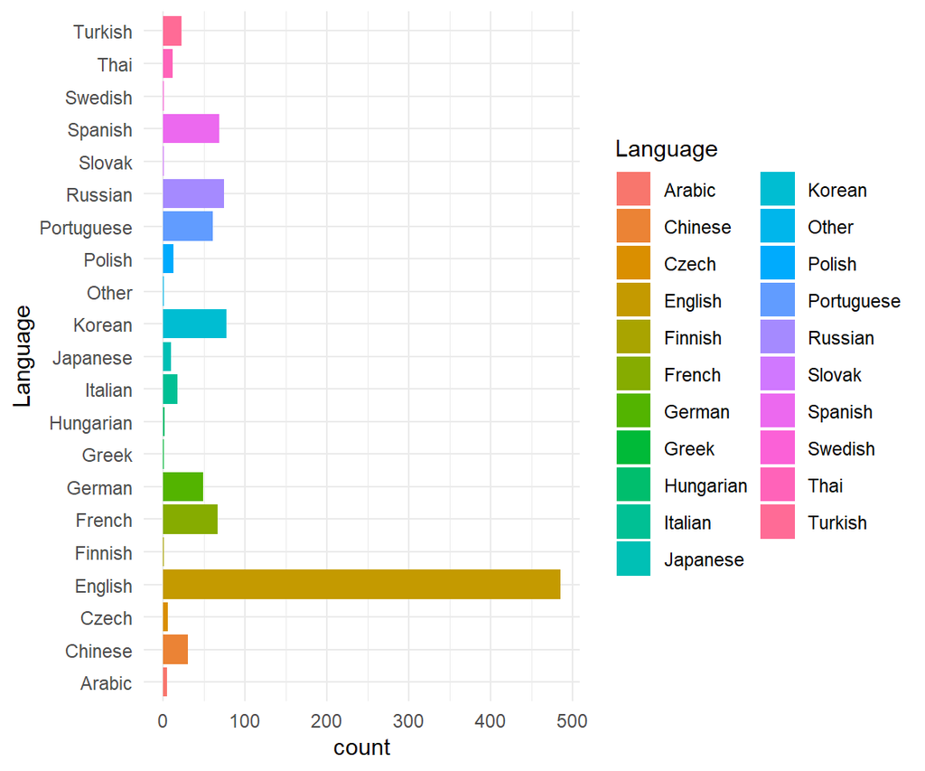

## Data Wrangling

*After this we made a graph of stream time verses followers gained. We then filtered them by language. However there didn’t appear to be any correlation. After this we were advised by our tutor to look at the log and square of the data and see if that produced a correlation, when that still didn’t show any strong correlation we decided to change our question slightly. To look at how follower numbers and followers gained are affected by various variables, namely Stream time and watch time.*

*When our data still did not show a correlation we decided to augment it by taking the log of our data and did our graphs using this:*

```r
twitchdata <- mutate(twitchdata,
                     Gain.percent = 100*Followers.gained/(Followers-Followers.gained),
                     log_Watch.time.Minutes. = log(Watch.time.Minutes.),
                     log_Followers = log(Followers),
                     log_Stream.time.minutes. = log(Stream.time.minutes.),
                     log_Average.viewers = log(Average.viewers))
language_data <- count(twitchdata, Language, sort= TRUE)
```

## Plots and Graphs

*In the following graphs, we only accounted for English-speaking streamers, and took the natural log of each variable. The graphs below represent the correlations between different variables of this data set, and can be used to predict the relationships that exist between them;*

*In this graph, we compared the values for Stream Time (the amount of time an individual streams on Twitch, in minutes) with the values for Watch Time (the amount of time spent by viewers watching the stream, in minutes). Between e^11 and e^12 minutes of stream time, there is a cluster of points, which may be a result of overrepresentation of individuals that stream for this amount of time.*

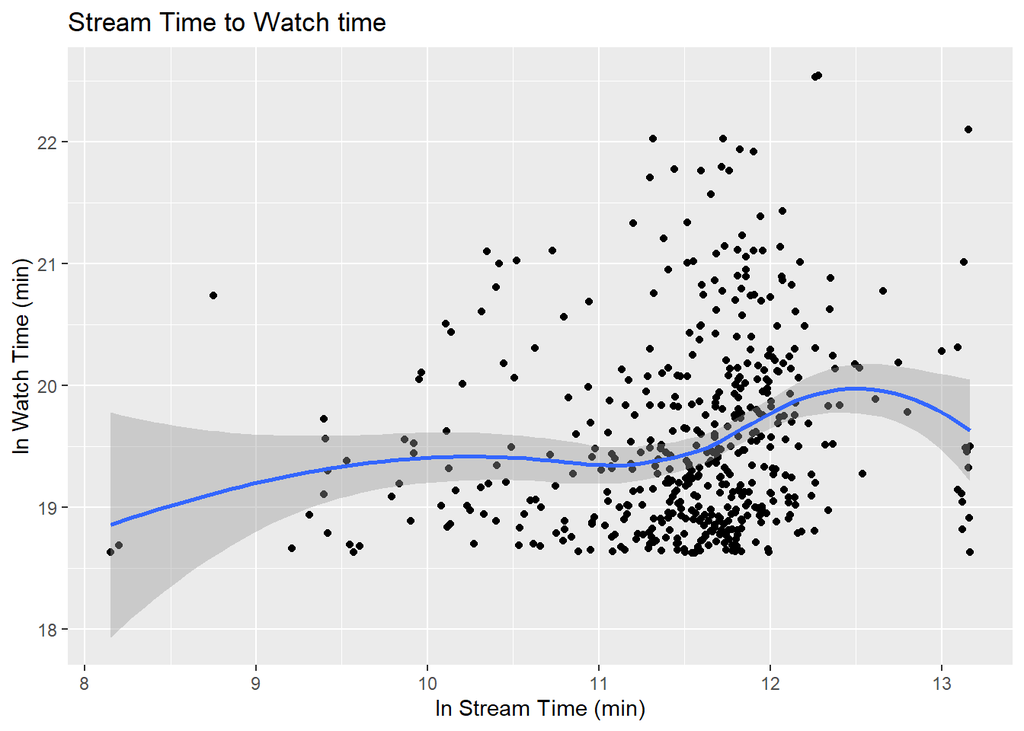

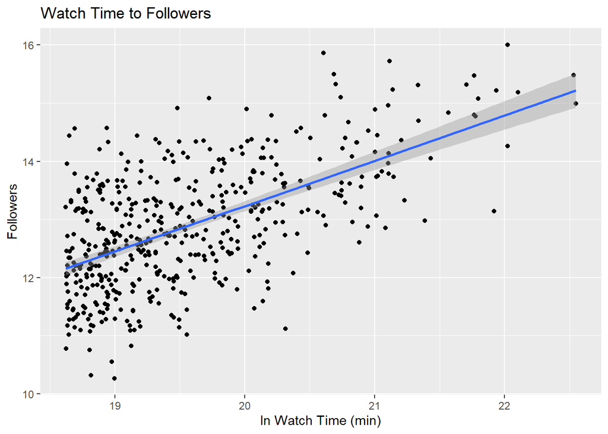

*This graph displays the relationship between a streamer’s watch time and the percent change in their amount of followers (Followers Gained). We filtered out data where the percentage of followers gained was an outlier (such as data points where a streamer suddenly gained an abnormally large amount of followers at once, which would have altered the validity of the relationship between variables). Similar to the graph above, Watch Time was taken as a natural log, with Followers Gained taken as a percentage.*

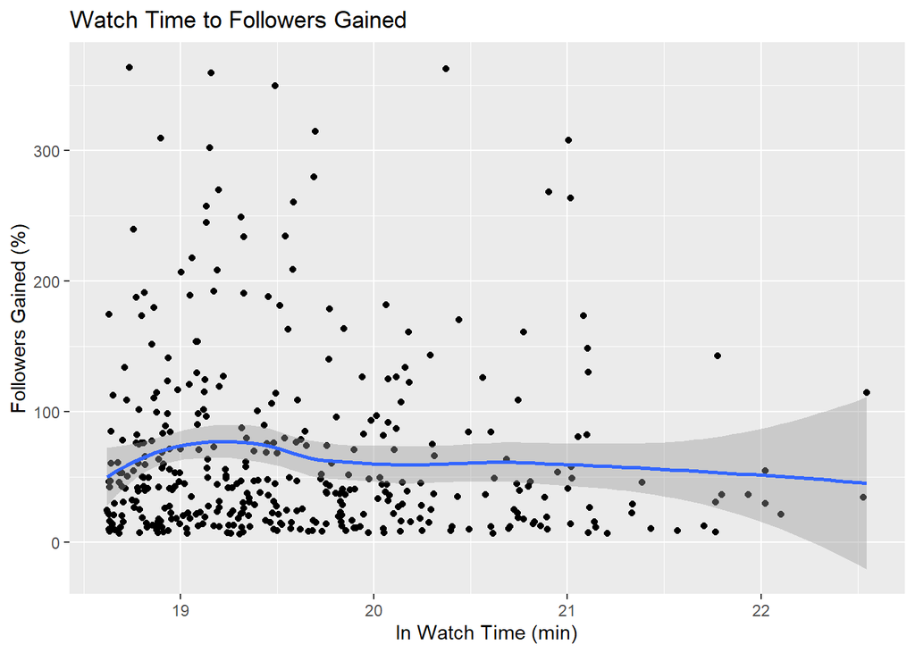

[figure not shown]

*This graph compares the amount of stream time with the average number of viewers watching the stream (represented by the Viewers variable), with the natural log taken of each variable. There is a large cluster of points between e^11 and e^12 minutes of stream time. There is a linear relationship that shows a shorter stream time being associated with a higher average number of viewers , and longer stream time with less average viewers.*

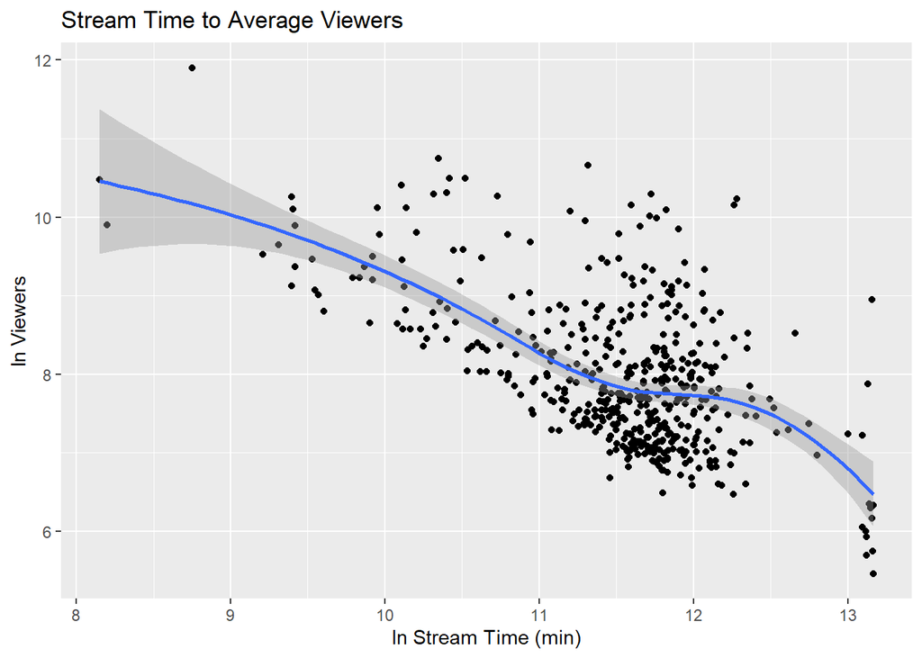

*This graph demonstrates how a streamer’s amount of followers affects the amount of average viewers for their streams. We also took the natural log of both variables to help establish a more clear relationship. As can be seen from the graph, as a streamer’s followers increase, their average viewers increase as well.*

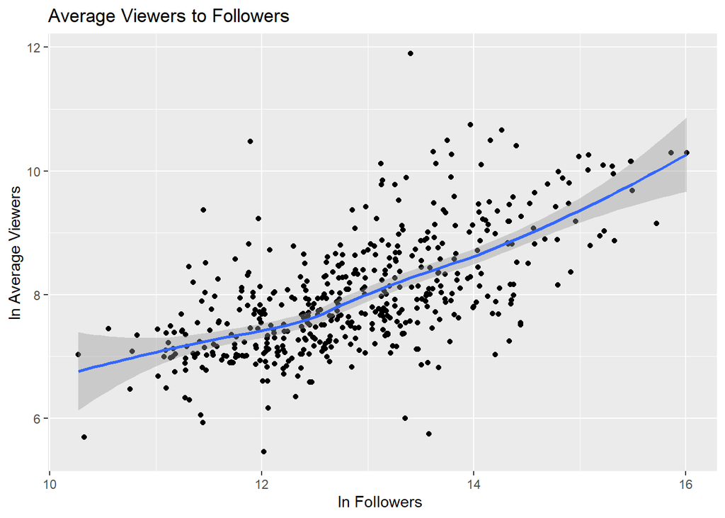

*In this graph, watch time is compared to average viewers, with the natural log taken of each variable again. There is a larger cluster of points on the lower end of the graph (lower watch time), especially between e^18 and e^20 minutes. Overall, the graph shows that a higher watch time is typically correlated with a higher count of average viewers.*

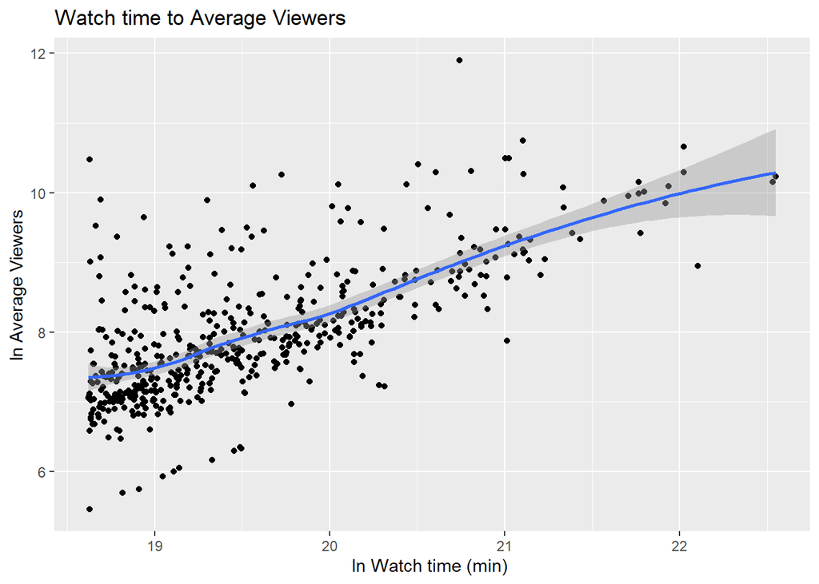

## Findings

*Our graphs show a strong link between the number of followers which increases as the stream time increases. Our graphs also indicate that the number of viewers decrease as the length of time a streamer streams increases but as average viewers increase the followers increase.*

## Models

*Anything with a 1 after it is part of the model for ln watch time by using ln stream time and ln followers. Anything with a 2 after it is for a model that predicts viewers based on followers, watch time and stream time. All models only work for english streamers. The first model has an r squared of 0.42, and the second has an r squared of 0.98.*

## Modelling

```r
englishdata <- filter(twitchdata, Language == "English")
set.seed(1234)
twitchdata_split <- initial_split(englishdata)
twitchdata_train <- training(twitchdata_split)
twitchdata_test  <- testing(twitchdata_split)
```

```r
twitchdata_spec <- linear_reg() %>%
  set_engine("lm")
```

### Watch time

*The following model predicts watch time by using both followers and stream time.*

```r
twitchdata_recipe_wtime <- recipe(log_Watch.time.Minutes. ~ log_Followers +
                                log_Stream.time.minutes.,
                      data = englishdata)
```

```r
twitchdata_wflow_wtime <- workflow() %>%
  add_model(twitchdata_spec) %>%
  add_recipe(twitchdata_recipe_wtime)
```

```r
twitchdata_fit_wtime <- twitchdata_wflow_wtime %>%
  fit(data = twitchdata_train)
tidy(twitchdata_fit_wtime)
```

```
## # A tibble: 3 × 5
##   term                     estimate std.error statistic  p.value
##   <chr>                       <dbl>     <dbl>     <dbl>    <dbl>
## 1 (Intercept)                 9.90     0.674      14.7  1.33e-38
## 2 log_Followers               0.464    0.0296     15.7  1.28e-42
## 3 log_Stream.time.minutes.    0.318    0.0414      7.68 1.55e-13
```

```r
twitchdata_pred_wtime <- predict(twitchdata_fit_wtime,
                             twitchdata_test) %>%
  bind_cols(twitchdata_test)
```

```r
glance(twitchdata_fit_wtime)$adj.r.squared
```

```
## [1] 0.4202266
```

### Viewers

*The following predits average viewers based on followers, watch time and stream time.*

```r
twitchdata_recipe_viewers <- recipe(log_Average.viewers ~ log_Followers +
                                log_Watch.time.Minutes. +
                                log_Stream.time.minutes.,
                              data = englishdata)
```

```r
twitchdata_wflow_viewers <- workflow() %>%
  add_model(twitchdata_spec) %>%
  add_recipe(twitchdata_recipe_viewers)
```

```r
twitchdata_fit_viewers <- twitchdata_wflow_viewers %>%
  fit(data = twitchdata_train)
tidy(twitchdata_fit_viewers)
```

```
## # A tibble: 4 × 5
##   term                     estimate std.error statistic   p.value
##   <chr>                       <dbl>     <dbl>     <dbl>     <dbl>
## 1 (Intercept)               -0.579    0.183       -3.16 1.72e-  3
## 2 log_Followers              0.0164   0.00824      2.00 4.67e-  2
## 3 log_Watch.time.Minutes.    0.982    0.0113      86.7  6.75e-243
## 4 log_Stream.time.minutes.  -0.944    0.00960    -98.4  8.60e-262
```

```r
twitchdata_pred_viewers <- predict(twitchdata_fit_viewers,
                             twitchdata_test) %>%
  bind_cols(twitchdata_test)
```

```r
glance(twitchdata_fit_viewers)$adj.r.squared
```

```
## [1] 0.9831478
```

## Evaluation

*Limitations: In the dataset there were multiple variables which could have affected the data collected and our analysis. We do not have information about the type of content being streamed, such as whether an individual is streaming video games, sports, music, or other types of content. We also do not know the subject or topic of the streams, which could be subject to internet trends and could affect their watch time, viewers, followers, and other variables. It is also important to consider that many Twitch streamers may already have a following on other platforms, and because of this, could subsequently have a higher number of viewers and followers on Twitch.*

*Through our graphs we showed multiple correlations, some expected such as when watch time increases the number of followers does too or similarly as stream time increases the number of followers increases as well. However, we also have some findings we did not expect such as, the longer stream time is the more the number of viewers declines. We also created two models one of which predicts average viewers based on followers, watch time and stream. These models can predict the average number of viewers with an r-squared value of 0.98.*

## Link to GitHub Repository

https://github.com/FibonAdi/Group_Project.git

## Data

Aayush Mishra, 2020, Top Streamers on Twitch, Electronic data set, Kaggle, Viewed 29th October 2022, https://www.kaggle.com/datasets/aayushmishra1512/twitchdata

## References

Wikipedia (2022), Twitch (service), viewed 25 November 2022, https://en.wikipedia.org/wiki/Twitch_(service)